# Practical 7

## Exercise 5

The `aatemp` data come from U.S. Historical Climatology network. They are the annual mean temperatures (in degrees F) in Ann Arbor, Michigan, going back about 150 year.

1. Regress the temperature against the year. Check the scatterplot temp vs year. Provide the $R^2$. Is there a linear trend?
2. Fit a polynomial model with degree 10. Provide the summary. What is the $R^2$? Is the model fit better with the polynomial?
3. Sequentially reduce the degree of the model (of degree 9, 8, etc.). Stop until the highest order term is significant. Which is the order of that model? What is the $R^2$?
4. Plot your fitted model (i.e., the curve) over the scatterplot of the data. Use this model to predict the temperature in 2020. Use `predict()` function (check the description in R).

For the orthogonal polynomials, we use the function `poly()`. Because the different terms are orthogonal, the sums of squares are not order dependent. So, we may look at the output from the order 10 polynomial to see which terms can be dropped. P-values will change only a bit if you would actually remove the terms, because the denominator of the F-statistics (or t-statistics) change slightly.

5. (Optional) Suppose someone claims that the temperature was constant until 1930 and then began a linear trend. In this situation, we could of fitting two regression models (before 1930 and after), however, the regression function won’t be continous. Instead, one can use *broken stick regression*, or more generally called segmented regression or piecewise regression. Define two basis functions:

$$\begin{gather*}
B_L(x)=
\begin{cases}
c - x & \text{if} x<c\\
0 & \text{otherwise}
\end{cases}
\end{gather*}$$
and

$$\begin{gather*}
B_R(x)=
\begin{cases}
x - c & \text{if} x > c\\
0 & \text{otherwise}
\end{cases}
\end{gather*}$$

Next, fit linear regression model $Y = \beta_0 + \beta_1 B_L(X) + \beta_2 B_R(X) + \epsilon$. Two regression lines are guaranteed to meet at $c$ (why?). Regression function is continuous now. Fit a model corresponding to this claim using `brokenstick()` function. What does the fitted model say about this claim? Also, plot the ordinary linear model obtained in a). Compare the results.

6. (Optional) Make a cubic spline fit with 6 basis functions evenly spaced on the range. Plot the fit in comparison to the previous fits. Does this model fit better than the straight line model? You can check this with the `anova()` function.

** Answers **

```r
head(aatemp)
```

```
##   year  temp
## 1 1854 49.15
## 2 1855 46.52
## 3 1871 48.80
## 4 1881 47.95
## 5 1882 47.31
## 6 1883 44.64
```

```r
olm <- lm(temp ~ year, aatemp)
summary(olm)
```

```
##
## Call:
## lm(formula = temp ~ year, data = aatemp)
##
## Residuals:
##     Min      1Q  Median      3Q     Max
## -3.9843 -0.9113 -0.0820  0.9946  3.5343
##
## Coefficients:
##              Estimate Std. Error t value Pr(>|t|)
## (Intercept) 24.005510   7.310781   3.284  0.00136 **
## year         0.012237   0.003768   3.247  0.00153 **
## ---
## Signif. codes:  0 '***' 0.001 '**' 0.01 '*' 0.05 '.' 0.1 ' ' 1
##
## Residual standard error: 1.466 on 113 degrees of freedom
## Multiple R-squared:  0.08536,    Adjusted R-squared:  0.07727
## F-statistic: 10.55 on 1 and 113 DF,  p-value: 0.001533
```

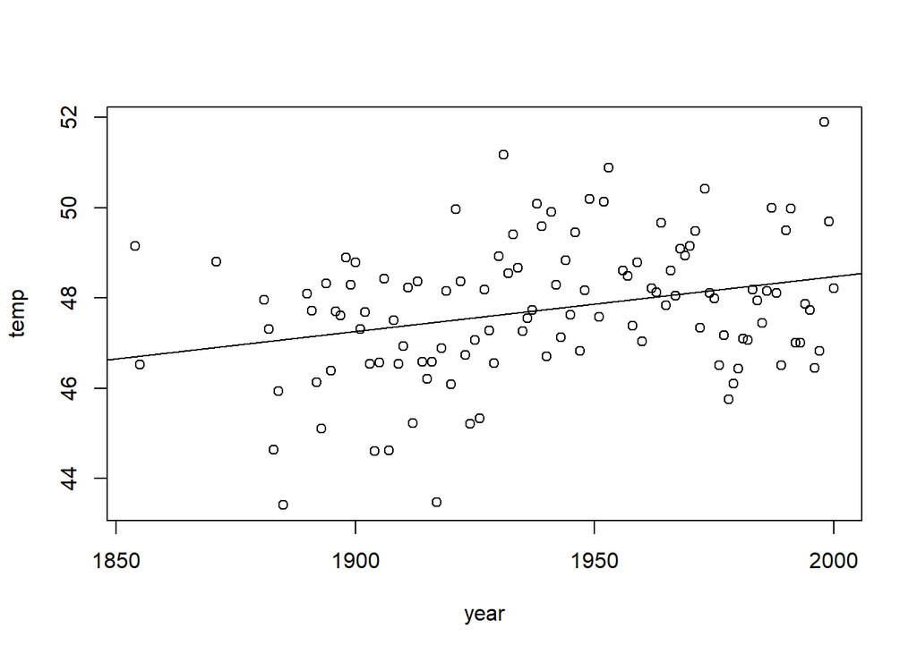

```r
plot(temp ~ year, data=aatemp)
abline(olm)
```

There seems to be a linear trend, according to the scatterplot with regression line and significant regression coefficient (small p-value, i.e., 0.0015). However, only 8% of the variation is explained by model (i.e., $R^2 = 0.085$), and some linear model assumptions may be violated. This is not the end of the story.

```r
#orthogonal polynomials
plm.10 <- lm(temp ~ poly(year, 10), data=aatemp)
summary(plm.10)
```

```
##
## Call:
## lm(formula = temp ~ poly(year, 10), data = aatemp)
##
## Residuals:
##     Min      1Q  Median      3Q     Max
## -3.4987 -0.8641 -0.1745  1.1450  3.4255
##
## Coefficients:
##                  Estimate Std. Error t value Pr(>|t|)
## (Intercept)       47.7426     0.1319 361.927  < 2e-16 ***
## poly(year, 10)1    4.7616     1.4146   3.366  0.00107 **
## poly(year, 10)2   -0.9071     1.4146  -0.641  0.52277
## poly(year, 10)3   -3.3132     1.4146  -2.342  0.02108 *
## poly(year, 10)4    2.4383     1.4146   1.724  0.08774 .
## poly(year, 10)5    3.3824     1.4146   2.391  0.01860 *
## poly(year, 10)6    1.2124     1.4146   0.857  0.39337
## poly(year, 10)7   -0.9373     1.4146  -0.663  0.50908
## poly(year, 10)8   -1.1011     1.4146  -0.778  0.43812
## poly(year, 10)9    1.3994     1.4146   0.989  0.32483
## poly(year, 10)10   0.3474     1.4146   0.246  0.80652
## ---
## Signif. codes:  0 '***' 0.001 '**' 0.01 '*' 0.05 '.' 0.1 ' ' 1
##
## Residual standard error: 1.415 on 104 degrees of freedom
## Multiple R-squared:  0.2165, Adjusted R-squared:  0.1411
## F-statistic: 2.873 on 10 and 104 DF,  p-value: 0.003335
```

3. The highest order term is not significant, thus, we try with degree 9, etc.

```r
plm.9 <- lm(temp ~ poly(year, 9), aatemp)
plm.8 <- lm(temp ~ poly(year, 8), aatemp)
plm.7 <- lm(temp ~ poly(year, 7), aatemp)
plm.6 <- lm(temp ~ poly(year, 6), aatemp)
plm.5 <- lm(temp ~ poly(year, 5), aatemp)
plm.4 <- lm(temp ~ poly(year, 4), aatemp)
plm.3 <- lm(temp ~ poly(year, 3), aatemp)
plm.2 <- lm(temp ~ poly(year, 2), aatemp)
summary(plm.9)
```

```
##
## Call:
## lm(formula = temp ~ poly(year, 9), data = aatemp)
##
## Residuals:
##     Min      1Q  Median      3Q     Max
## -3.4836 -0.8831 -0.2156  1.1354  3.3936
##
## Coefficients:
##                Estimate Std. Error t value Pr(>|t|)
## (Intercept)     47.7426     0.1313 363.557  < 2e-16 ***
## poly(year, 9)1   4.7616     1.4083   3.381  0.00101 **
## poly(year, 9)2  -0.9071     1.4083  -0.644  0.52089
## poly(year, 9)3  -3.3132     1.4083  -2.353  0.02050 *
## poly(year, 9)4   2.4383     1.4083   1.731  0.08631 .
## poly(year, 9)5   3.3824     1.4083   2.402  0.01807 *
## poly(year, 9)6   1.2124     1.4083   0.861  0.39123
## poly(year, 9)7  -0.9373     1.4083  -0.666  0.50716
## poly(year, 9)8  -1.1011     1.4083  -0.782  0.43605
## poly(year, 9)9   1.3994     1.4083   0.994  0.32265
## ---
## Signif. codes:  0 '***' 0.001 '**' 0.01 '*' 0.05 '.' 0.1 ' ' 1
##
## Residual standard error: 1.408 on 105 degrees of freedom
## Multiple R-squared:  0.216,  Adjusted R-squared:  0.1488
## F-statistic: 3.215 on 9 and 105 DF,  p-value: 0.001769
```

```r
summary(plm.8)
```

```
##
## Call:
## lm(formula = temp ~ poly(year, 8), data = aatemp)
##
## Residuals:
##     Min      1Q  Median      3Q     Max
## -3.6086 -0.8600 -0.2385  1.0608  3.3975
##
## Coefficients:
##                Estimate Std. Error t value Pr(>|t|)
## (Intercept)     47.7426     0.1313 363.579  < 2e-16 ***
## poly(year, 8)1   4.7616     1.4082   3.381  0.00101 **
## poly(year, 8)2  -0.9071     1.4082  -0.644  0.52085
## poly(year, 8)3  -3.3132     1.4082  -2.353  0.02047 *
## poly(year, 8)4   2.4383     1.4082   1.732  0.08626 .
## poly(year, 8)5   3.3824     1.4082   2.402  0.01805 *
## poly(year, 8)6   1.2124     1.4082   0.861  0.39118
## poly(year, 8)7  -0.9373     1.4082  -0.666  0.50713
## poly(year, 8)8  -1.1011     1.4082  -0.782  0.43600
## ---
## Signif. codes:  0 '***' 0.001 '**' 0.01 '*' 0.05 '.' 0.1 ' ' 1
##
## Residual standard error: 1.408 on 106 degrees of freedom
## Multiple R-squared:  0.2086, Adjusted R-squared:  0.1489
## F-statistic: 3.494 on 8 and 106 DF,  p-value: 0.001284
```

```r
summary(plm.7)
```

```
##
## Call:
## lm(formula = temp ~ poly(year, 7), data = aatemp)
##
## Residuals:
##     Min      1Q  Median      3Q     Max
## -3.5922 -0.9032 -0.2322  0.9880  3.2941
##
## Coefficients:
##                Estimate Std. Error t value Pr(>|t|)
## (Intercept)     47.7426     0.1311 364.241  < 2e-16 ***
## poly(year, 7)1   4.7616     1.4056   3.388 0.000988 ***
## poly(year, 7)2  -0.9071     1.4056  -0.645 0.520083
## poly(year, 7)3  -3.3132     1.4056  -2.357 0.020234 *
## poly(year, 7)4   2.4383     1.4056   1.735 0.085672 .
## poly(year, 7)5   3.3824     1.4056   2.406 0.017828 *
## poly(year, 7)6   1.2124     1.4056   0.863 0.390303
## poly(year, 7)7  -0.9373     1.4056  -0.667 0.506341
## ---
## Signif. codes:  0 '***' 0.001 '**' 0.01 '*' 0.05 '.' 0.1 ' ' 1
##
## Residual standard error: 1.406 on 107 degrees of freedom
## Multiple R-squared:  0.2041, Adjusted R-squared:  0.152
## F-statistic: 3.919 on 7 and 107 DF,  p-value: 0.0007651
```

```r
summary(plm.6)
```

```
##
## Call:
## lm(formula = temp ~ poly(year, 6), data = aatemp)
##
## Residuals:
##     Min      1Q  Median      3Q     Max
## -3.6846 -0.8825 -0.1428  0.9388  3.2950
##
## Coefficients:
##                Estimate Std. Error t value Pr(>|t|)
## (Intercept)     47.7426     0.1307 365.181  < 2e-16 ***
## poly(year, 6)1   4.7616     1.4020   3.396 0.000957 ***
## poly(year, 6)2  -0.9071     1.4020  -0.647 0.518996
## poly(year, 6)3  -3.3132     1.4020  -2.363 0.019905 *
## poly(year, 6)4   2.4383     1.4020   1.739 0.084851 .
## poly(year, 6)5   3.3824     1.4020   2.413 0.017527 *
## poly(year, 6)6   1.2124     1.4020   0.865 0.389067
## ---
## Signif. codes:  0 '***' 0.001 '**' 0.01 '*' 0.05 '.' 0.1 ' ' 1
##
## Residual standard error: 1.402 on 108 degrees of freedom
## Multiple R-squared:  0.2008, Adjusted R-squared:  0.1564
## F-statistic: 4.522 on 6 and 108 DF,  p-value: 0.0003978
```

```r
summary(plm.5)
```

```
##
## Call:
## lm(formula = temp ~ poly(year, 5), data = aatemp)
##
## Residuals:
##     Min      1Q  Median      3Q     Max
## -3.7142 -0.9198 -0.1420  0.9903  3.2364
##
## Coefficients:
##                Estimate Std. Error t value Pr(>|t|)
## (Intercept)     47.7426     0.1306 365.604  < 2e-16 ***
## poly(year, 5)1   4.7616     1.4004   3.400 0.000942 ***
## poly(year, 5)2  -0.9071     1.4004  -0.648 0.518500
## poly(year, 5)3  -3.3132     1.4004  -2.366 0.019749 *
## poly(year, 5)4   2.4383     1.4004   1.741 0.084470 .
## poly(year, 5)5   3.3824     1.4004   2.415 0.017384 *
## ---
## Signif. codes:  0 '***' 0.001 '**' 0.01 '*' 0.05 '.' 0.1 ' ' 1
##
## Residual standard error: 1.4 on 109 degrees of freedom
## Multiple R-squared:  0.1952, Adjusted R-squared:  0.1583
## F-statistic: 5.289 on 5 and 109 DF,  p-value: 0.0002176
```

The first significant term has power 5.

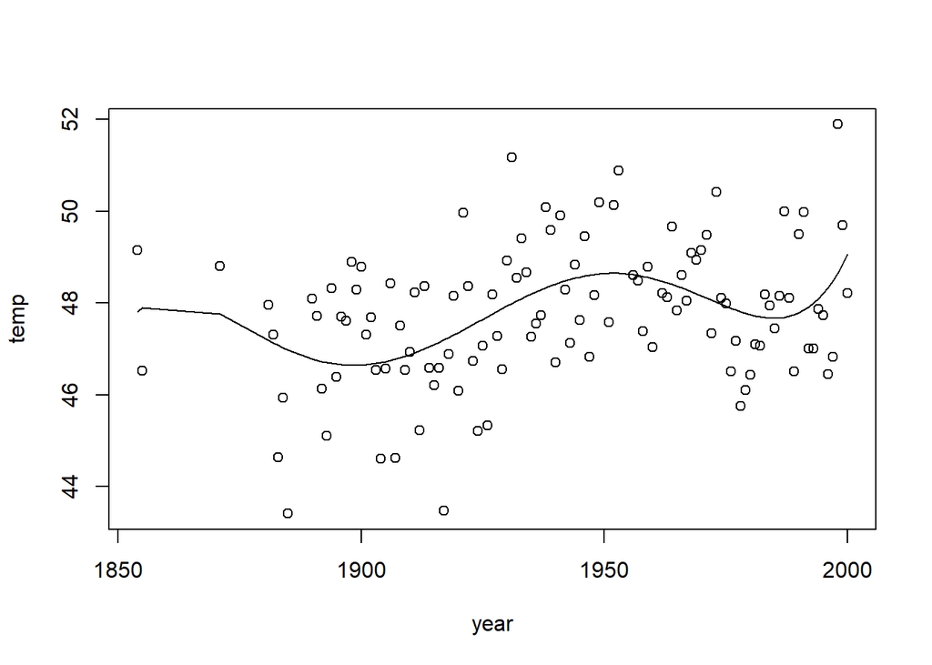

```r
plot(temp ~ year, data=aatemp)
lines(aatemp$year, fitted(plm.5))
```

```r
d2020 <- data.frame(year=2020)
predict(plm.5, d2020)
```

```
##        1
## 60.07774
```

Note that the predicted temperature is based on extrapolation, and is highly unlikely.

```r
# First, let's run two regression models, befor and after 1930 (not needed)
  g1 <- lm(temp ~ year, aatemp, subset=(year<1930))
  g2 <- lm(temp ~ year, aatemp, subset=(year>=1930))
  plot(aatemp$year, aatemp$temp, xlab="Year", ylab="temp")
  abline(v=1930, lty=5)
  range(aatemp$year)
```

```
## [1] 1854 2000
```

```r
  segments(1850, g1$coef[1]+g1$coef[2]*1850, 1930, g1$coef[1]+g1$coef[2]*1930, lty=2)
  segments(2010, g2$coef[1]+g2$coef[2]*2010, 1930, g2$coef[1]+g2$coef[2]*1930, lty=2)

  #Now, let's use broken stick regression
  lhs <- function(x) ifelse(x<1930, 1930-x, 0) # not needed
  rhs <- function(x) ifelse(x<1930, 0, x-1930)
  brokenstick <- lm(temp ~ rhs(year), aatemp)
  summary(brokenstick)
```

```
##
## Call:
## lm(formula = temp ~ rhs(year), data = aatemp)
##
## Residuals:
##     Min      1Q  Median      3Q     Max
## -4.0222 -0.8872 -0.0355  0.9628  3.7229
##
## Coefficients:
##              Estimate Std. Error t value Pr(>|t|)
## (Intercept) 47.432151   0.184604 256.939   <2e-16 ***
## rhs(year)    0.014970   0.005857   2.556   0.0119 *
## ---
## Signif. codes:  0 '***' 0.001 '**' 0.01 '*' 0.05 '.' 0.1 ' ' 1
##
## Residual standard error: 1.491 on 113 degrees of freedom
## Multiple R-squared:  0.05465,    Adjusted R-squared:  0.04628
## F-statistic: 6.532 on 1 and 113 DF,  p-value: 0.01192
```

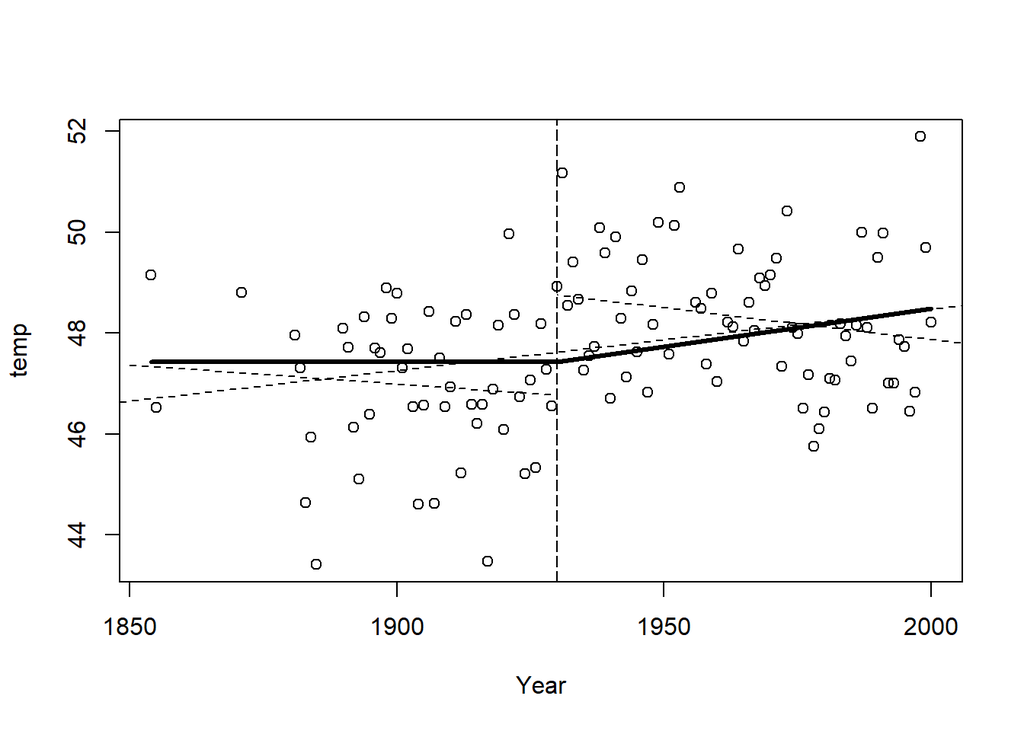

```r
  xx <- 1854:2000
  pre <- brokenstick$coef[1] + brokenstick$coef[2]*rhs(xx)
  lines(xx, pre, lwd= 3)
  abline(olm, lty=2)
```

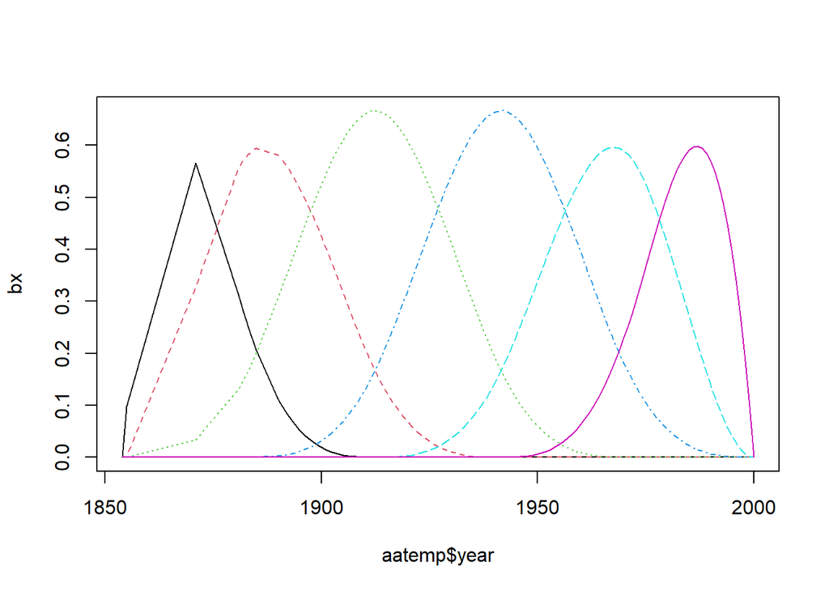

```r
knots <- c(rep(1854,2), seq(1854, 2000, length=6), rep(2000,2))
bx <- splineDesign(knots, aatemp$year, outer.ok=TRUE)
matplot(aatemp$year, bx, type="l")
```

```r
slm <- lm(temp ~ bx, data=aatemp)
summary(slm)
```

```
##
## Call:
## lm(formula = temp ~ bx, data = aatemp)
##
## Residuals:
##     Min      1Q  Median      3Q     Max
## -3.5927 -0.8714 -0.1545  1.0068  3.4224
##
## Coefficients:
##             Estimate Std. Error t value Pr(>|t|)
## (Intercept)  48.7935     0.6210  78.571  < 2e-16 ***
## bx1          -2.6599     2.5426  -1.046  0.29785
## bx2          -1.1686     1.3377  -0.874  0.38430
## bx3          -2.7454     0.9559  -2.872  0.00491 **
## bx4           0.4496     0.9920   0.453  0.65128
## bx5          -0.5051     0.9185  -0.550  0.58351
## bx6          -1.7437     1.2488  -1.396  0.16547
## ---
## Signif. codes:  0 '***' 0.001 '**' 0.01 '*' 0.05 '.' 0.1 ' ' 1
##
## Residual standard error: 1.403 on 108 degrees of freedom
## Multiple R-squared:  0.1999, Adjusted R-squared:  0.1554
## F-statistic: 4.496 on 6 and 108 DF,  p-value: 0.0004197
```

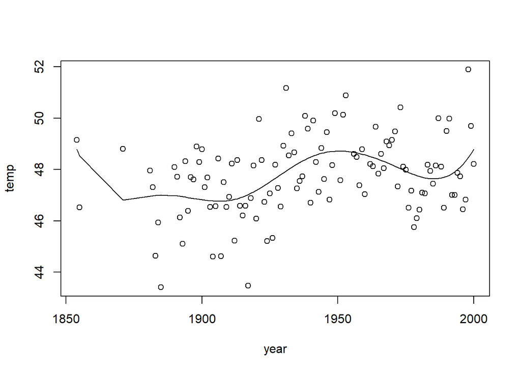

```r
plot(temp ~ year, data=aatemp)
lines(aatemp$year, slm$fitted)
```

To check whether spline model outperforms the straight line model, use `anova()` function.

```r
anova(olm, slm)
```

```
## Analysis of Variance Table
##
## Model 1: temp ~ year
## Model 2: temp ~ bx
##   Res.Df    RSS Df Sum of Sq     F  Pr(>F)
## 1    113 242.94
## 2    108 212.53  5    30.413 3.091 0.01201 *
## ---
## Signif. codes:  0 '***' 0.001 '**' 0.01 '*' 0.05 '.' 0.1 ' ' 1
```

The analysis shows that the more complex function is better than the smaller one (linear model).